```
   a)Après lecture de ce fichier  en python, il s'agis d'un filtrage FIR (non recursive)
```

# -> b)réponse fréquentielle du filtre

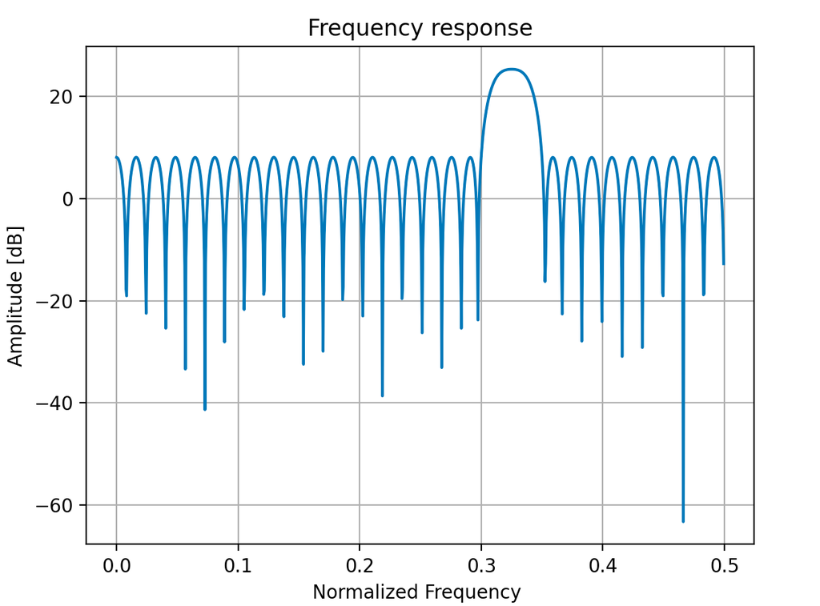

- caractéristique du filtre: on attenue d'environ **15 DB** entre

**F1=0.00 et F2=0.29 puis entre F3= O.35 et F4=0.5**

Les frequences sont normalisées **(fs=1)**

nombre de coef ***64***

freq = **0.09765625** | H = (**-1.888808451958261+1.6496184527290072j**)

amplitude **2.52816088608128**

Gain **8.056094158931844**dB

```python
import numpy as np
import scipy.signal as sci
import matplotlib.pyplot as plt
import serial
import struct
import time
%matplotlib qt



coef=np.loadtxt("coef21.txt")
b=coef
a=1
#nombre de coeficientes
N = len(coef)
print('nombre de coef',N)
#print(coef)
M=1024 #number of samples for the simulation
imp=np.zeros(M)
imp[0]=1 #create an impulse signal
h=sci.lfilter(b,a,imp) #h is the impulse response of this filter
# réponse fréquentielle
H=np.fft.fft(h) # FFT
w,H= sci.freqz(b,a,worN=1024,fs=1) # frequency response
plt.figure()
plt.plot(w,10*np.log10(np.abs(H)**2)) # Power scale
print(f'freq = {w[200]} | H = {H[300]}')
T=np.abs(H[200])
print(f'amplitude {T}')
# Gain in dB
Gian=20*np.log10(T)
print(f'Gain {Gian} dB')
plt.title('Frequency response')
plt.xlabel('Normalized Frequency ')
plt.ylabel('Amplitude [dB]')
plt.grid()
```

# c)teste du filtre sur les signaux de références differentes:

# -> réponse impulsionnelle

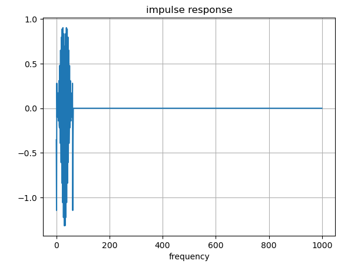

```python
#résponse impultionnelle
M=1024 #number of samples for the simulation
imp=np.zeros(M)
imp[0]=1 #create an impulse signal

plt.figure()
h=sci.lfilter(b,a,imp) #h is the impulse response of this filter
plt.plot(h[:1000])  # here, just the first 100 samples. to have the full plot plt.plot(h)
plt.xlabel("frequency")
plt.ylabel(" ")
plt.title("impulse response")
plt.grid()
```

```
 ▪ réponse à un sinus, essayez plusieurs fréquences. Montrer que vous êtes capable de
  prédire l’amplitude de sortie et vérifier votre résultat en simulation python
```

***max_s = 5.0559***

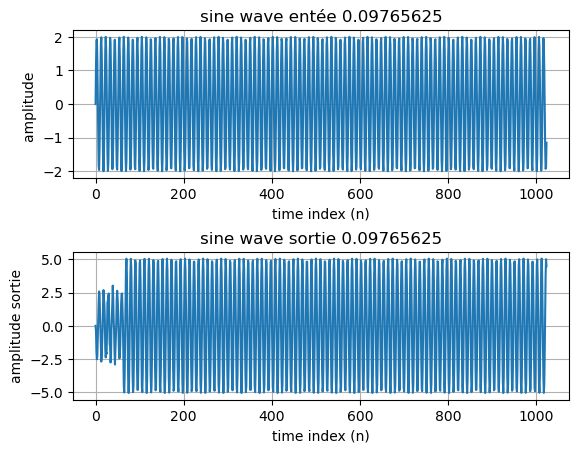

pour une frequence de **0.0977**, on obtien -theoriquemen une amplitude de sortie de :**5.0563** -expérimentalement une amplitude de sortie de :**5.0559**

***max_s = 35.2849***

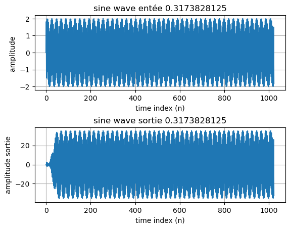

pour une frequence de **0.3174**, on obtien -theoriquemen une amplitude de sortie de :**35.2851** -expérimentalement une amplitude de sortie de :**35.2849**

***max_s = 4.1512***

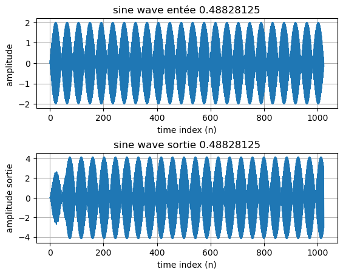

pour une frequence de **0.4883**, on obtien -theoriquemen une amplitude de sortie de :**4.1515** -expérimentalement une amplitude de sortie de :**4.1512**

max_s = **5.0559** max_s = **35.2849** max_s = **4.1512**

freq = **0.0977** | Gian = **8.0561 dB** | amplitude_filtre = **2.5282** | amplitudde_sinus_sortie = **5.0563**

freq = **0.3174** | Gian =**24.9312 dB** | amplitude_filtre = **17.6426** | amplitudde_sinus_sortie=**35.2851**

freq = **0.4883** | Gian = **6.3436 dB** | amplitude_filtre = **2.0758** | amplitudde_sinus_sortie = **4.1515**

```python
#réponse à un signal sinusoïdal
fo=[w[200],w[650],w[1000]] #frequency of the sine wave
#n=np.linspace(0,100,M) #time index
n=np.arange(0,M) #time index
print(n)
for i in range(len(fo)):
    x=2*np.sin(2*np.pi*n*fo[i]) #the sine wave
    s=sci.lfilter(b,a,x) #s is the output of the filter
    max_s=np.max(s[64:])
    print(f' max_s = {max_s:.4f} ')
    plt.figure()
    plt.subplot(211)
    plt.plot(n,x)
    plt.xlabel("time index (n)")
    plt.ylabel("amplitude ")
    plt.title(f"sine wave entée {fo[i]}")
    plt.grid()

    plt.subplot(212)
    plt.plot(n,s)
    plt.xlabel("time index (n)")
    plt.ylabel("amplitude sortie")
    plt.title(f"sine wave sortie {fo[i]}")
    plt.grid()
    #espacer les figures
    plt.subplots_adjust(hspace=0.5)
    plt.show()


index=200
T=np.abs(H[index])
Gian=20*np.log10(T)
print(f'freq = {w[index]:.4f} | Gian = {Gian:.4f} dB | amplitude_filtre = {T:.4f} | amplitudde_sinus_sortie = {2*T:.4f}')
index=650
T=np.abs(H[index])
Gian=20*np.log10(T)
print(f'freq = {w[index]:.4f} | Gian = {Gian:.4f} dB | amplitude_filtre = {T:.4f} | amplitudde_sinus_sortie = {2*T:.4f}')
index=1000
T=np.abs(H[index])
Gian=20*np.log10(T)
print(f'freq = {w[index]:.4f} | Gian = {Gian:.4f} dB | amplitude_filtre = {T:.4f} | amplitudde_sinus_sortie = {2*T:.4f}')

"""
 max_s = 5.0559
 max_s = 35.2849
 max_s = 4.1512
freq = 0.0977 | Gian = 8.0561 dB | amplitude_filtre = 2.5282 | amplitudde_sinus_sortie = 5.0563
freq = 0.3174 | Gian = 24.9312 dB | amplitude_filtre = 17.6426 | amplitudde_sinus_sortie=35.2851
freq = 0.4883 | Gian = 6.3436 dB | amplitude_filtre = 2.0758 | amplitudde_sinus_sortie = 4.1515
"""
```

```
 ▪ Bruit blanc gaussien. Montrez que vous êtes capable de prédire la puissance de sortie
```

et vérifiez votre résultat en simulation python.

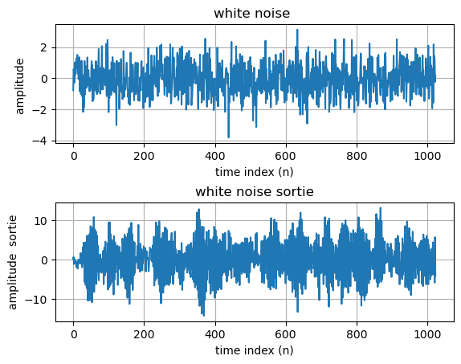

-puissance du bruit en entrée = ***1.0262***

-puissance du bruit en sortie = ***26.5798***

-puissance du bruit en sortie (théorique) = ***23.9998***

```python
#réponse a un bruit blanc gaussien
noise=np.random.randn(M)
y_bruit=sci.lfilter(b,a,noise)

plt.figure()
plt.subplot(211)
plt.plot(noise)
plt.xlabel("time index (n)")
plt.ylabel("amplitude ")
plt.title("white noise ")
plt.grid()

plt.subplot(212)
plt.plot(y_bruit)
plt.xlabel("time index (n)")
plt.ylabel("amplitude  sortie")
plt.title("white noise sortie")
plt.grid()
plt.subplots_adjust(hspace=0.5)

#puissance du bruit en sortie
P_bruit=np.mean(noise**2)
print(f'puissance du bruit en entrée = {P_bruit:.4f}')
P_bruit_sortie=np.mean(y_bruit**2)
print(f'puissance du bruit en sortie = {P_bruit_sortie:.4f}')


# puissance de sortie théorique
P_bruit_theorique=np.sum(b**2)*P_bruit
print(f'puissance de sortie théorique = {P_bruit_theorique:.4f}')
```

# codage optimal en virgule fixe pour ces coefficients.

Ntotal = E + F + 1

- 1 bit pour le signe (car les coefficient sont signés)
- E bits pour la partie entière
- F bits pour la partie fractionnaire

coef_min = -1.3157415252968885

coef_max = 0.9031506811907334

donc

abs(coef_min) = 1.3157415252968885

abs(coef_max) = 0.9031506811907334

→ le max est 1.3157415252968885

ceil(0.3958761024487547) → 1.0

integer_bits = 1

donc E = 1.0

F= Ntotal - E - 1

F= 16 - 1 - 1 = 14

```
Fixed-point coefficients:pour arduino
```

**[ -5793 -18755 4594 -1676 1906 -1619 -496 2832 -2327 -1635 5068 -3111 -3597 7837 -3400 -6429 10659 -2805 -9959 13060 -1185 -13749 14549 1394 -17309 14797 4703 -20049 13694 8195 -21557 11360 11360 -21557 8195 13694 -20049 4703 14797 -17309 1394 14549 -13749 -1185 13060 -9959 -2805 10659 -6429 -3400 7837 -3597 -3111 5068 -1635 -2327 2832 -496 -1619 1906 -1676 4594 -18755 -5793]**

```python
# Determine the range of coefficients
coef_min = np.min(coef)
coef_max = np.max(coef)
print(f'Min coefficient: {coef_min}, Max coefficient: {coef_max}')

# Calculate the number of integer bits required
integer_bits = int(np.ceil(np.log2(max(abs(coef_min), abs(coef_max))))) # Calculate the number of bits needed to represent the integer part
print(f'Number of integer bits required: {integer_bits}')
# Number of integer bits required: 1
"""
Exemple:
coef_min = -10
coef_max = 8
Then:
abs(coef_min) = 10, abs(coef_max) = 8 → max is 10
log2(10) ≈ 3.32
ceil(3.32) → 4
integer_bits = 4
This means 4 bits are needed to represent values up to ±10."""


# Define the total number of bits for fixed-point representation
total_bits = 16  # Example: using 16-bit fixed-point representation

# Calculate the number of fractional bits
fractional_bits = total_bits - integer_bits - 1  # Subtract 1 for the sign bit
print(f'Number of fractional bits: {fractional_bits}')

# Calcul du facteur d’échelle
scaling_factor = 2 ** fractional_bits
"""
Exemple : si fractional_bits = 8, alors scaling_factor = 256.
Cela signifie que 0.5 deviendra 128 (0.5 * 256 = 128).
"""
fixed_point_coef = np.round(coef * scaling_factor).astype(int)
print(f'Fixed-point coefficients:pour arduino \n {fixed_point_coef}')
```

# Trouver le format de codage optimal des opérandes et des opérateurs pour éviter les dépassements et maximiser la précision

$y(n)=\sum_{i=0}^{64} b_i * x(n-i)$

- $b_i : Q(16, 14)$
- $x(n) : Q(16, 6)$
- $mult = b_i*x(n) : Q(32, 20)$

- $sum = \sum_{i=0}^{64} mult : Q(64, 20)$
- $y(n) : Q(16, 6)$

```python
# Étape 1 : Déterminer la plage des coefficients
coef_range = (coef_min, coef_max)
print(f"Plage des coefficients : {coef_range}")

# Étape 2 : Calculer la plage des valeurs intermédiaires (produits)
# Les produits sont calculés entre les coefficients et les valeurs d'entrée (par exemple, l'impulsion ou un signal sinusoïdal ou un bruit)
# Supposons que l'entrée est normalisée entre -1 et 1
input_range = (0, 1)
product_min = coef_min * input_range[0]
product_max = coef_max * input_range[1]
product_range = (min(product_min, product_max), max(product_min, product_max))
print(f"Plage des produits intermédiaires : {product_range}")

# Étape 3 : Calculer la plage des accumulations
# L'accumulation est la somme des produits intermédiaires
# La valeur maximale d'accumulation est obtenue en supposant que tous les coefficients sont positifs
accumulation_max = np.sum(np.abs(coef))
accumulation_min = -accumulation_max
accumulation_range = (accumulation_min, accumulation_max)
print(f"Plage des accumulations : {accumulation_range}")

# Étape 4 : Déterminer le nombre de bits nécessaires pour éviter les dépassements
# Le nombre de bits pour la partie entière doit couvrir la plage des accumulations
integer_bits_accumulation = int(np.ceil(np.log2(max(abs(accumulation_min), abs(accumulation_max)))))
print(f"Nombre de bits pour la partie entière (accumulation) : {integer_bits_accumulation}")

# Étape 5 : Maximiser la précision
# Le nombre total de bits est défini (par exemple, 16 bits)
# Les bits restants après la partie entière sont utilisés pour la partie fractionnaire
fractional_bits_accumulation = total_bits - integer_bits_accumulation - 1  # -1 pour le bit de signe
print(f"Nombre de bits pour la partie fractionnaire (accumulation) : {fractional_bits_accumulation}")

# Résumé du format optimal
print(f"Format optimal : {integer_bits_accumulation} bits pour la partie entière, "
    f"{fractional_bits_accumulation} bits pour la partie fractionnaire.")
```

[output not shown]

```
Vérification  de la réponse impulsionnelle et la
réponse à une fréquence avec les coef imlplémenté dans arduino.


réponse à une fréquence
```

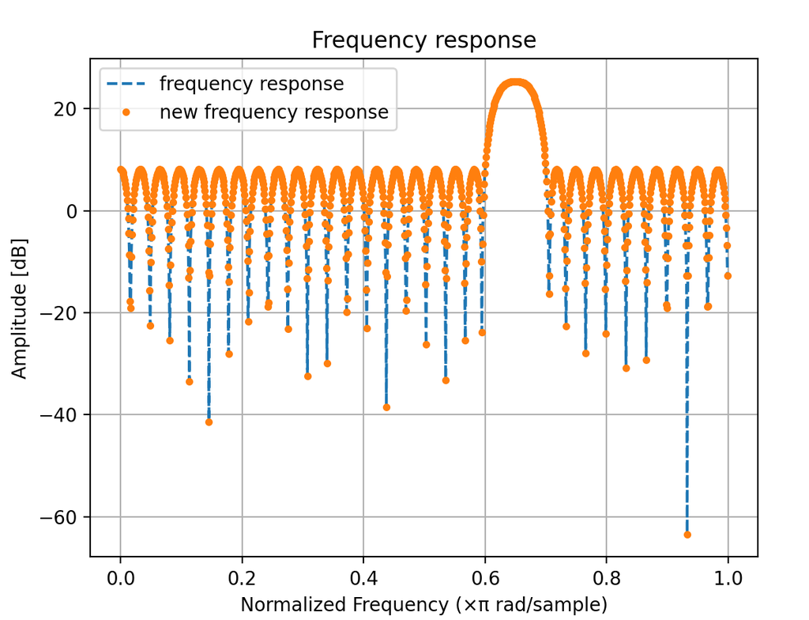

```
 réponse impulsionnelle
```

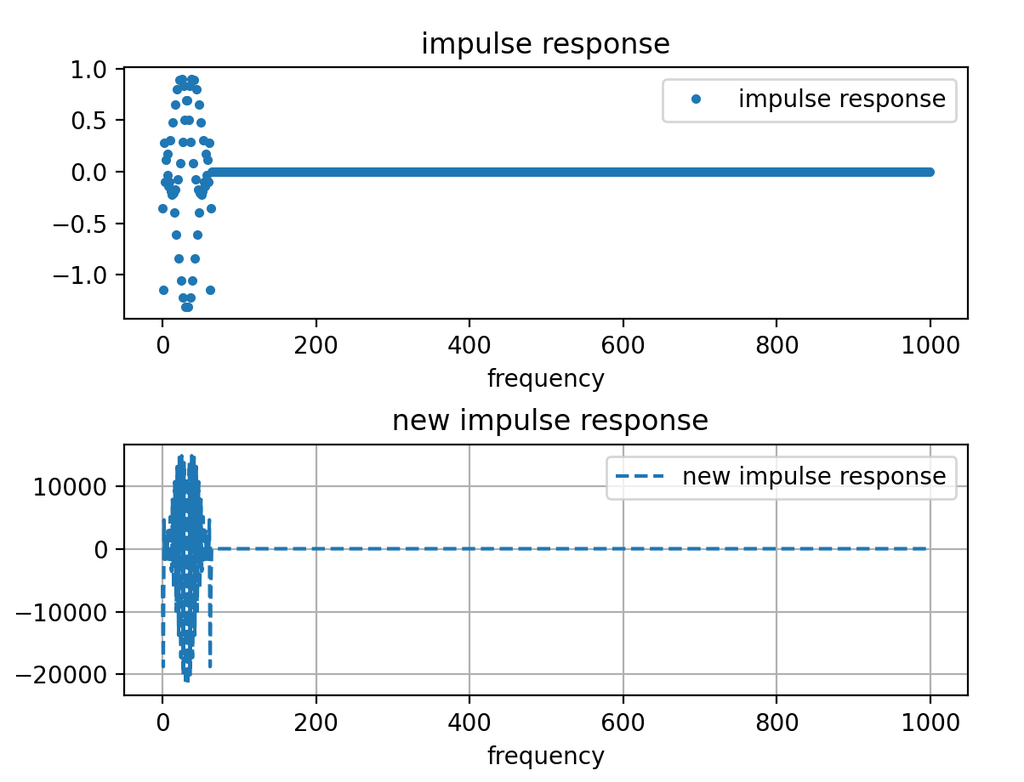

**coef pour arduino**

b=[ -5793. -18755. 4594. -1676. 1906. -1619. -496. 2832. -2327. -1635. 5068. -3111. -3597. 7837. -3400. -6429. 10659. -2805. -9959. 13060. -1185. -13749. 14549. 1394. -17309. 14797. 4703. -20049. 13694. 8195. -21557. 11360. 11360. -21557. 8195. 13694. -20049. 4703. 14797. -17309. 1394. 14549. -13749. -1185. 13060. -9959. -2805. 10659. -6429. -3400. 7837. -3597. -3111. 5068. -1635. -2327. 2832. -496. -1619. 1906. -1676. 4594. -18755. -5793.]

a = 1

```python
import numpy as np
import scipy.signal
import matplotlib.pyplot as plt
#%matplotlib qt


coef=np.loadtxt("coef21.txt", delimiter=',')
b=coef
a=1
#print(b,"a = ",a)
# Point fixed values of the coefficients:
Fc=14
coef = np.round(coef * 2**Fc) / 2**Fc # rounding to 14 bits
b1=coef
a1=1
#print("new  \n",b1,"a = ",a)

# int14_t values of the coefficients:
coef = np.round(coef * 2**Fc) # rounding to 14 bits
b2=coef
a2=1
print("coef pour arduino  \n" ,b2,"a = ",a)

# Plot the frequency response
w, h = scipy.signal.freqz(b, a, worN=1024)
w1, h1 = scipy.signal.freqz(b1, a, worN=1024)

plt.figure()
plt.plot(w/np.pi, 20 * np.log10(abs(h)),'--',label="frequency response") # Magnitude in dB
plt.plot(w1/np.pi, 20 * np.log10(abs(h1)),'.',label="new frequency response") # Magnitude in dB
plt.title('Frequency response')
plt.xlabel('Normalized Frequency (×π rad/sample)')
plt.ylabel('Amplitude [dB]')
plt.grid()
plt.legend()
plt.show()


#résponse impultionnelle
M=1024 #number of samples for the simulation
imp=np.zeros(M)
imp[0]=1 #create an impulse signal
h=sci.lfilter(b,a,imp)
h2=sci.lfilter(b2,a,imp) #h is the impulse response of this filter

plt.figure()
plt.subplot(211)
plt.plot(h[:1000],'.',label="impulse response") # here, just the first 100 samples. to have the full plot plt.plot(h)
plt.title("impulse response")
plt.xlabel("frequency")
plt.legend()
plt.subplot(212)
plt.plot(h2[:1000],'--',label="new impulse response")
plt.title(" new impulse response")
plt.xlabel("frequency")
plt.ylabel(" ")
plt.grid()
plt.legend()
plt.subplots_adjust(hspace=0.5)
plt.show()
```

```
Envoi d'une suite d’échantillons sur la liaison série de l’Arduino, traitement l’échantillon dans l’arduino puis renvoi de la valeur traitée par liaison série au programme python.
```

```python
# === CONFIGURATION ===

t=np.arange(M)
PORT = '/dev/cu.usbmodem143301'
BAUDRATE = 115200
#N_SAMPLES = M

# === INITIALISATION SERIAL ===
ser = serial.Serial(PORT, BAUDRATE, timeout=1)
time.sleep(2)  # laisser le temps à l’Arduino de démarrer


# create the impulse signal
imp=np.zeros(M)
imp[0]=1

# === GÉNÉRER SIGNAL ===
#t = np.arange(N_SAMPLES)
freq = 0.4
amplitude = 3
#signal=(imp).astype(np.int16)
#signal
signal = (amplitude * np.cos(2 * np.pi * freq * t)).astype(np.int16)
#noise
#bruit = np.random.normal(0, 10, N_SAMPLES).astype(np.int16)
#signal = signal + bruit
#signal = signal.astype(np.int16)
# === ENVOI & RÉCEPTION ===
output = []
for x in signal:
    # envoyer en little endian
    ser.write(struct.pack('<h', x))

    # lire réponse filtrée
    response = ser.read(2)
    if len(response) == 2:
        yn = struct.unpack('<h', response)[0]
        output.append(yn)
    else:
        output.append(0)  # ou None si besoin
"""
#frequency response of the filter
HH=np.fft.fft(output)
f,HH=sci.freqz(b1, a1, worN=M, fs=1)"""

# === AFFICHAGE ===
plt.figure()
plt.title("Filtrage FIR temps réel via Arduino")
plt.subplot(211)
plt.plot(signal, label='Entrée (x[n])')
plt.xlabel("temps")
plt.ylabel("x[n]")
plt.legend()
plt.grid()
plt.subplots_adjust(hspace=0.5)

plt.subplot(212)
plt.plot(output, label='Sortie filtrée (y[n])')
plt.xlabel("temps")
plt.ylabel("y[n]")
plt.legend()
plt.grid()
plt.subplots_adjust(hspace=0.5)

"""
plt.subplot(3,1,3)
plt.plot(f, 10*np.log10(np.abs(HH)**2), label="frequency response")
plt.xlabel("normalized frequency")
plt.ylabel("psd [dB]")
plt.legend()
plt.grid()"""

# === FIN ===
ser.close()
```

```
 implémentation du filtre en arduino avec un  signal d’entrée  généré par un GBF (enplitude 5volts avec u n efréquence de 100 Hz )
```

**->En vert c'ets l'entrée : GBF** 5**V.**

**->En rose c'est la sortie : après passage dans le filtre**

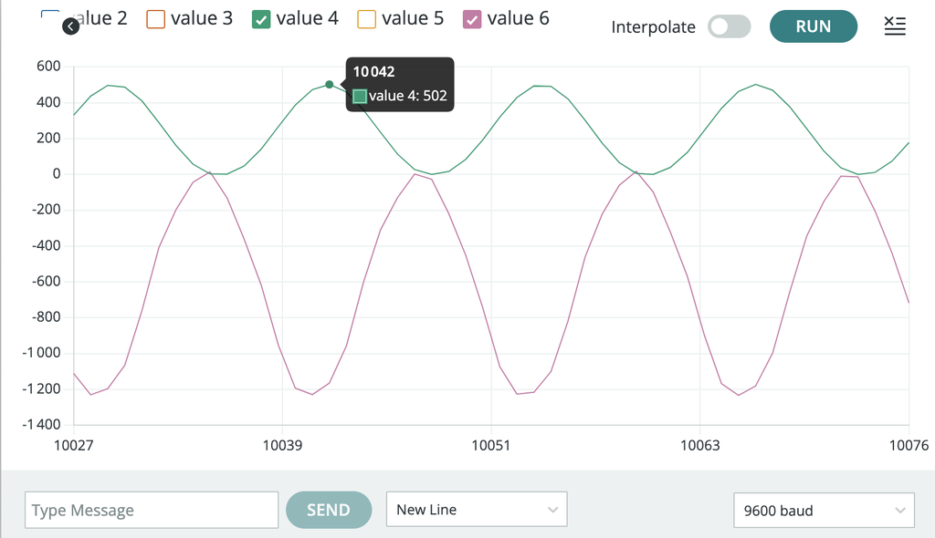